# Lab Assigment 3

Akshay Yadav

The given data on scores for students measured before and after exam has 2 distinct types of columns. One type is where the variables are expected to have different values for before (**pre**) and after (**post**) taking the exams. The columns like **total** and the columns containing the individual answer scores are included in this type. The other type of columns have variables with values that are expected to remain same before and after the exams. This category includes columns like **Gender, Normalized Changes, Characteristic**.

We have designed a function *read_exam_data* that will read in the data from file and assign missing values. The function performs following operations and returns a dataframe.

- Takes the file name and the sheet numver to read the data. Only the columns containing the columns that are common to all the four sheets in both the files are read since we need to combine all the data together. Only the columns containing the student-ids, the type of the score *(pre/post)* information, the total scores, the gender information, the two treatment information, the characteristic information and normalized change scores are read. The first 2 columns are assigned names - *id* and *scoretype*.

```r
library(tidyverse)
library(ggplot2)

get_unique_values<-function(x){
  u_len<-length(unique(x[!is.na(x)]))
  if(u_len==0){
    return("NA")
  }else if(u_len==2){
    return(paste(unique(x[!is.na(x)]),collapse=","))
  } else {
    return(unique(x[!is.na(x)]))
  }
}

read_exam_data <- function(file="Spreadsheets/FileOne.xlsx", sem=1, exam=1){
score_table<-readxl::read_excel(path=file, sheet=sem)
names(score_table)[1]<-"id"
names(score_table)[2]<-"scoretype"
colnames(score_table) <- tolower(colnames(score_table))
score_table <- score_table %>% select(id, scoretype, starts_with("gen"),
                  starts_with("treatme"),
                  starts_with("charac"),
                  starts_with("tot"),
                  starts_with("norm"))

names(score_table)<- c("id", "scoretype", "gender",
                    "treat1", "treat2",
                    "characteristic",
                    "total","normchange")

uval_table<-score_table %>% group_by(id) %>%
  select(id,normchange,gender,treat1,treat2,characteristic) %>%
  summarise(gender=get_unique_values(unique(gender[!is.na(gender)])),
            normchange=get_unique_values(unique(normchange[!is.na(normchange)])),
            characteristic=get_unique_values(unique(characteristic[!is.na(characteristic)])),
            treat1=get_unique_values(unique(treat1[!is.na(treat1)])),
            treat2=get_unique_values(unique(treat2[!is.na(treat2)])))


nuval_table<-score_table %>% select(id,scoretype,total)
new_score_table<-full_join(uval_table,nuval_table,by="id")
new_score_table$semester<-rep(sem,dim(new_score_table)[1])
new_score_table$exam<-rep(exam,dim(new_score_table)[1])

return(new_score_table)
}
```

Calling the *read_exam_data* function for each sheet (semester) to prepare a master data table containing data for all 4 semesters and both the exams

```r
master_table<-read_exam_data(file="Spreadsheets/FileOne.xlsx", sem=1, exam=1)
master_table<-rbind(master_table,read_exam_data(file="Spreadsheets/FileOne.xlsx", sem=2, exam=1))
master_table<-rbind(master_table,read_exam_data(file="Spreadsheets/FileOne.xlsx", sem=3, exam=1))
master_table<-rbind(master_table,read_exam_data(file="Spreadsheets/FileOne.xlsx", sem=4, exam=1))

master_table<-rbind(master_table,read_exam_data(file="Spreadsheets/FileTwo.xlsx", sem=1, exam=2))
master_table<-rbind(master_table,read_exam_data(file="Spreadsheets/FileTwo.xlsx", sem=2, exam=2))
master_table<-rbind(master_table,read_exam_data(file="Spreadsheets/FileTwo.xlsx", sem=3, exam=2))
master_table<-rbind(master_table,read_exam_data(file="Spreadsheets/FileTwo.xlsx", sem=4, exam=2))
```

All the character data containing columns need to converted to lower-case

```r
master_table<-data.frame(lapply(master_table, function(v) {
  if (is.character(v)) return(tolower(v))
  else return(v)
}))
```

Converting the *gender*, *semester*, and *exam* columns as factor data so for consistency and to get distinct colors in the graphs

```r
master_table$gender<-as.factor(master_table$gender)
master_table$semester<-as.factor(master_table$semester)
master_table$exam<-as.factor(master_table$exam)
```

Plotting the *pre v/s post* values for both the exams faceted by semester. The different colors represent different exams and the different shapes of the points represent the different genders

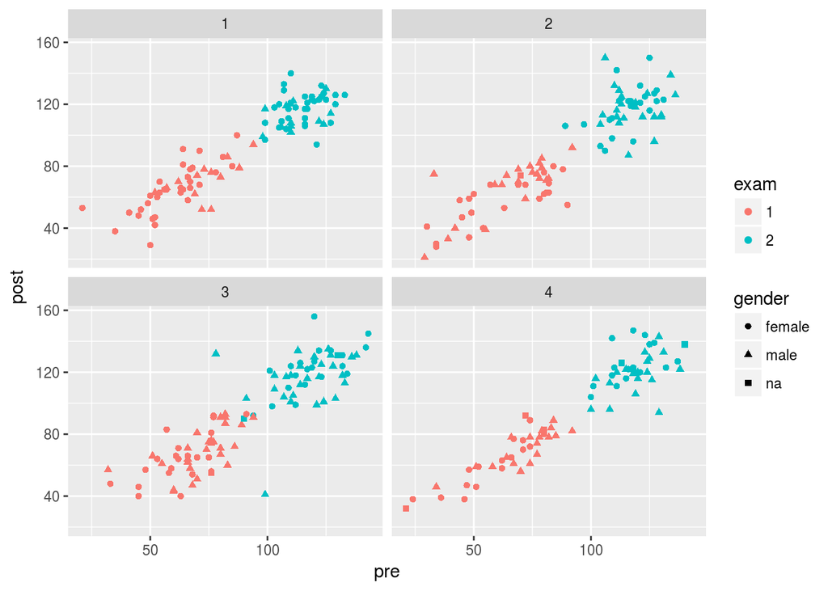

```r
master_table %>% spread(scoretype,total) %>%
  ggplot(aes(x = pre, y = post,color=exam)) +
  geom_point(aes(shape=gender)) +
  facet_wrap(~semester)
```